# Project: Identify Customer Segments

In this project, you will apply unsupervised learning techniques to identify segments of the population that form the core customer base for a mail-order sales company in Germany. These segments can then be used to direct marketing campaigns towards audiences that will have the highest expected rate of returns. The data that you will use has been provided by our partners at Bertelsmann Arvato Analytics, and represents a real-life data science task.

This notebook will help you complete this task by providing a framework within which you will perform your analysis steps. In each step of the project, you will see some text describing the subtask that you will perform, followed by one or more code cells for you to complete your work. **Feel free to add additional code and markdown cells as you go along so that you can explore everything in precise chunks.** The code cells provided in the base template will outline only the major tasks, and will usually not be enough to cover all of the minor tasks that comprise it.

It should be noted that while there will be precise guidelines on how you should handle certain tasks in the project, there will also be places where an exact specification is not provided. **There will be times in the project where you will need to make and justify your own decisions on how to treat the data.** These are places where there may not be only one way to handle the data. In real-life tasks, there may be many valid ways to approach an analysis task. One of the most important things you can do is clearly document your approach so that other scientists can understand the decisions you've made.

At the end of most sections, there will be a Markdown cell labeled **Discussion**. In these cells, you will report your findings for the completed section, as well as document the decisions that you made in your approach to each subtask. **Your project will be evaluated not just on the code used to complete the tasks outlined, but also your communication about your observations and conclusions at each stage.**

```python
# import libraries here; add more as necessary
import ast
import numpy as np
import pandas as pd
import matplotlib.pyplot as plt
import seaborn as sns
from sklearn.preprocessing import StandardScaler
from sklearn.decomposition import PCA
from sklearn.cluster import KMeans

# magic word for producing visualizations in notebook
%matplotlib inline

'''
Import note: The classroom currently uses sklearn version 0.19.
If you need to use an imputer, it is available in sklearn.preprocessing.Imputer,
instead of sklearn.impute as in newer versions of sklearn.
'''
```

```
'\nImport note: The classroom currently uses sklearn version 0.19.\nIf you need to use an imputer, it is available in sklearn.preprocessing.Imputer,\ninstead of sklearn.impute as in newer versions of sklearn.\n'
```

### Step 0: Load the Data

There are four files associated with this project (not including this one):

Each row of the demographics files represents a single person, but also includes information outside of individuals, including information about their household, building, and neighborhood. You will use this information to cluster the general population into groups with similar demographic properties. Then, you will see how the people in the customers dataset fit into those created clusters. The hope here is that certain clusters are over-represented in the customers data, as compared to the general population; those over-represented clusters will be assumed to be part of the core userbase. This information can then be used for further applications, such as targeting for a marketing campaign.

To start off with, load in the demographics data for the general population into a pandas DataFrame, and do the same for the feature attributes summary. Note for all of the `.csv` data files in this project: they're semicolon (`;`) delimited, so you'll need an additional argument in your [`read_csv()`](https://pandas.pydata.org/pandas-docs/stable/generated/pandas.read_csv.html) call to read in the data properly. Also, considering the size of the main dataset, it may take some time for it to load completely.

Once the dataset is loaded, it's recommended that you take a little bit of time just browsing the general structure of the dataset and feature summary file. You'll be getting deep into the innards of the cleaning in the first major step of the project, so gaining some general familiarity can help you get your bearings.

```python
# Load in the general demographics data.
azdias = pd.read_csv('Udacity_AZDIAS_Subset.csv', delimiter=";")

# Load in the feature summary file.
feat_info = pd.read_csv('AZDIAS_Feature_Summary.csv', delimiter=";")
```

```python
# Check the structure of the data after it's loaded (e.g. print the number of
# rows and columns, print the first few rows).
display(azdias.head(5))
display(azdias.describe())
```

|  | AGER_TYP | ALTERSKATEGORIE_GROB | ANREDE_KZ | CJT_GESAMTTYP | FINANZ_MINIMALIST | FINANZ_SPARER | FINANZ_VORSORGER | FINANZ_ANLEGER | FINANZ_UNAUFFAELLIGER | FINANZ_HAUSBAUER | ... | PLZ8_ANTG1 | PLZ8_ANTG2 | PLZ8_ANTG3 | PLZ8_ANTG4 | PLZ8_BAUMAX | PLZ8_HHZ | PLZ8_GBZ | ARBEIT | ORTSGR_KLS9 | RELAT_AB |
| --- | --- | --- | --- | --- | --- | --- | --- | --- | --- | --- | --- | --- | --- | --- | --- | --- | --- | --- | --- | --- | --- |
| 0 | -1 | 2 | 1 | 2.0 | 3 | 4 | 3 | 5 | 5 | 3 | ... | NaN | NaN | NaN | NaN | NaN | NaN | NaN | NaN | NaN | NaN |
| 1 | -1 | 1 | 2 | 5.0 | 1 | 5 | 2 | 5 | 4 | 5 | ... | 2.0 | 3.0 | 2.0 | 1.0 | 1.0 | 5.0 | 4.0 | 3.0 | 5.0 | 4.0 |
| 2 | -1 | 3 | 2 | 3.0 | 1 | 4 | 1 | 2 | 3 | 5 | ... | 3.0 | 3.0 | 1.0 | 0.0 | 1.0 | 4.0 | 4.0 | 3.0 | 5.0 | 2.0 |
| 3 | 2 | 4 | 2 | 2.0 | 4 | 2 | 5 | 2 | 1 | 2 | ... | 2.0 | 2.0 | 2.0 | 0.0 | 1.0 | 3.0 | 4.0 | 2.0 | 3.0 | 3.0 |
| 4 | -1 | 3 | 1 | 5.0 | 4 | 3 | 4 | 1 | 3 | 2 | ... | 2.0 | 4.0 | 2.0 | 1.0 | 2.0 | 3.0 | 3.0 | 4.0 | 6.0 | 5.0 |

5 rows × 85 columns

|  | AGER_TYP | ALTERSKATEGORIE_GROB | ANREDE_KZ | CJT_GESAMTTYP | FINANZ_MINIMALIST | FINANZ_SPARER | FINANZ_VORSORGER | FINANZ_ANLEGER | FINANZ_UNAUFFAELLIGER | FINANZ_HAUSBAUER | ... | PLZ8_ANTG1 | PLZ8_ANTG2 | PLZ8_ANTG3 | PLZ8_ANTG4 | PLZ8_BAUMAX | PLZ8_HHZ | PLZ8_GBZ | ARBEIT | ORTSGR_KLS9 | RELAT_AB |
| --- | --- | --- | --- | --- | --- | --- | --- | --- | --- | --- | --- | --- | --- | --- | --- | --- | --- | --- | --- | --- | --- |
| count | 891221.000000 | 891221.000000 | 891221.000000 | 886367.000000 | 891221.000000 | 891221.000000 | 891221.000000 | 891221.000000 | 891221.000000 | 891221.000000 | ... | 774706.000000 | 774706.000000 | 774706.000000 | 774706.000000 | 774706.000000 | 774706.000000 | 774706.000000 | 794005.000000 | 794005.000000 | 794005.00000 |
| mean | -0.358435 | 2.777398 | 1.522098 | 3.632838 | 3.074528 | 2.821039 | 3.401106 | 3.033328 | 2.874167 | 3.075121 | ... | 2.253330 | 2.801858 | 1.595426 | 0.699166 | 1.943913 | 3.612821 | 3.381087 | 3.167854 | 5.293002 | 3.07222 |
| std | 1.198724 | 1.068775 | 0.499512 | 1.595021 | 1.321055 | 1.464749 | 1.322134 | 1.529603 | 1.486731 | 1.353248 | ... | 0.972008 | 0.920309 | 0.986736 | 0.727137 | 1.459654 | 0.973967 | 1.111598 | 1.002376 | 2.303739 | 1.36298 |
| min | -1.000000 | 1.000000 | 1.000000 | 1.000000 | 1.000000 | 1.000000 | 1.000000 | 1.000000 | 1.000000 | 1.000000 | ... | 0.000000 | 0.000000 | 0.000000 | 0.000000 | 1.000000 | 1.000000 | 1.000000 | 1.000000 | 0.000000 | 1.00000 |
| 25% | -1.000000 | 2.000000 | 1.000000 | 2.000000 | 2.000000 | 1.000000 | 3.000000 | 2.000000 | 2.000000 | 2.000000 | ... | 1.000000 | 2.000000 | 1.000000 | 0.000000 | 1.000000 | 3.000000 | 3.000000 | 3.000000 | 4.000000 | 2.00000 |
| 50% | -1.000000 | 3.000000 | 2.000000 | 4.000000 | 3.000000 | 3.000000 | 3.000000 | 3.000000 | 3.000000 | 3.000000 | ... | 2.000000 | 3.000000 | 2.000000 | 1.000000 | 1.000000 | 4.000000 | 3.000000 | 3.000000 | 5.000000 | 3.00000 |
| 75% | -1.000000 | 4.000000 | 2.000000 | 5.000000 | 4.000000 | 4.000000 | 5.000000 | 5.000000 | 4.000000 | 4.000000 | ... | 3.000000 | 3.000000 | 2.000000 | 1.000000 | 3.000000 | 4.000000 | 4.000000 | 4.000000 | 7.000000 | 4.00000 |
| max | 3.000000 | 9.000000 | 2.000000 | 6.000000 | 5.000000 | 5.000000 | 5.000000 | 5.000000 | 5.000000 | 5.000000 | ... | 4.000000 | 4.000000 | 3.000000 | 2.000000 | 5.000000 | 5.000000 | 5.000000 | 9.000000 | 9.000000 | 9.00000 |

8 rows × 81 columns

```python
display(feat_info.head(5))
display(feat_info.describe())
```

|  | attribute | information_level | type | missing_or_unknown |
| --- | --- | --- | --- | --- |
| 0 | AGER_TYP | person | categorical | [-1,0] |
| 1 | ALTERSKATEGORIE_GROB | person | ordinal | [-1,0,9] |
| 2 | ANREDE_KZ | person | categorical | [-1,0] |
| 3 | CJT_GESAMTTYP | person | categorical | [0] |
| 4 | FINANZ_MINIMALIST | person | ordinal | [-1] |

|  | attribute | information_level | type | missing_or_unknown |
| --- | --- | --- | --- | --- |
| count | 85 | 85 | 85 | 85 |
| unique | 85 | 9 | 5 | 9 |
| top | SEMIO_MAT | person | ordinal | [-1] |
| freq | 1 | 43 | 49 | 26 |

```python
azdias_empty_raw = azdias.isnull().sum()
```

```python
# Identify missing or unknown data values and convert them to NaNs.
feat_info['missing_or_unknown'] = feat_info['missing_or_unknown'].apply(lambda x: ast.literal_eval(x.replace("X", "'X'").replace("XX", "'XX'")))
for idx, el in feat_info.iterrows():
    for i in el['missing_or_unknown']:
        attr = el['attribute']
        azdias[attr].replace(i, np.NaN, inplace=True)
print((azdias.isnull().sum() - azdias_empty_raw).sum())
```

```
3477091
```

#### Step 1.1.2: Assess Missing Data in Each Column

How much missing data is present in each column? There are a few columns that are outliers in terms of the proportion of values that are missing. You will want to use matplotlib's [`hist()`](https://matplotlib.org/api/_as_gen/matplotlib.pyplot.hist.html) function to visualize the distribution of missing value counts to find these columns. Identify and document these columns. While some of these columns might have justifications for keeping or re-encoding the data, for this project you should just remove them from the dataframe. (Feel free to make remarks about these outlier columns in the discussion, however!)

For the remaining features, are there any patterns in which columns have, or share, missing data?

```python
nonZeroAzDias = azdias.isnull().sum()
nonZeroAzDias = nonZeroAzDias[nonZeroAzDias > 0].sort_values()
```

```python
nonZeroAzDias
```

```
ALTERSKATEGORIE_GROB       2881
CJT_GESAMTTYP              4854
GFK_URLAUBERTYP            4854
ONLINE_AFFINITAET          4854
RETOURTYP_BK_S             4854
LP_STATUS_FEIN             4854
LP_STATUS_GROB             4854
HH_EINKOMMEN_SCORE        18348
ANZ_PERSONEN              73499
SOHO_KZ                   73499
ANZ_TITEL                 73499
WOHNDAUER_2008            73499
KONSUMNAEHE               73969
LP_FAMILIE_GROB           77792
LP_FAMILIE_FEIN           77792
GEBAEUDETYP               93148
WOHNLAGE                  93148
OST_WEST_KZ               93148
MIN_GEBAEUDEJAHR          93148
GEBAEUDETYP_RASTER        93155
EWDICHTE                  93740
BALLRAUM                  93740
INNENSTADT                93740
LP_LEBENSPHASE_GROB       94572
ANZ_HH_TITEL              97008
ORTSGR_KLS9               97274
ARBEIT                    97375
RELAT_AB                  97375
LP_LEBENSPHASE_FEIN       97632
CAMEO_DEUG_2015           99352
                          ...
CAMEO_INTL_2015           99352
ANZ_HAUSHALTE_AKTIV       99611
KBA13_ANZAHL_PKW         105800
PRAEGENDE_JUGENDJAHRE    108164
NATIONALITAET_KZ         108315
HEALTH_TYP               111196
VERS_TYP                 111196
SHOPPER_TYP              111196
PLZ8_ANTG2               116515
PLZ8_ANTG3               116515
PLZ8_ANTG1               116515
PLZ8_ANTG4               116515
PLZ8_BAUMAX              116515
PLZ8_HHZ                 116515
PLZ8_GBZ                 116515
KBA05_ANTG3              133324
KBA05_ANTG2              133324
KBA05_ANTG1              133324
MOBI_REGIO               133324
KBA05_GBZ                133324
KBA05_ANTG4              133324
W_KEIT_KIND_HH           147988
KKK                      158064
REGIOTYP                 158064
ALTER_HH                 310267
GEBURTSJAHR              392318
KBA05_BAUMAX             476524
KK_KUNDENTYP             584612
AGER_TYP                 685843
TITEL_KZ                 889061
Length: 61, dtype: int64
```

## Bar plot with sum of null values per attribute

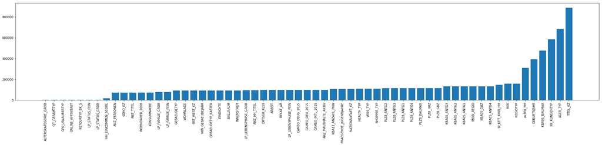

```python
# Perform an assessment of how much missing data there is in each column of the
# dataset.

index = np.arange(len(nonZeroAzDias.index))
labels = nonZeroAzDias.index

fig = plt.figure(figsize=(35,6))
ax = fig.add_subplot(111)

ax.bar(index, nonZeroAzDias.values)
plt.xticks(index, labels, fontsize=10, rotation=90)
plt.show()
```

```python
nonZeroAzDias.describe()
```

```
count        61.000000
mean     137277.524590
std      157099.496443
min        2881.000000
25%       93148.000000
50%       99352.000000
75%      116515.000000
max      889061.000000
dtype: float64
```

### Lets identify the outlier using boxplot

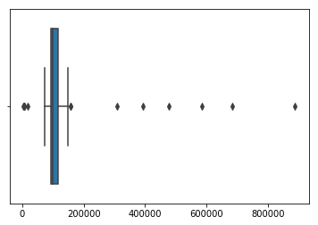

```python
sns.boxplot(nonZeroAzDias);
```

```python
# Investigate patterns in the amount of missing data in each column.
# Let's get all attributes that have more than 200k empty values
top6 = nonZeroAzDias[nonZeroAzDias > 200000]
print(top6)
```

```
ALTER_HH        310267
GEBURTSJAHR     392318
KBA05_BAUMAX    476524
KK_KUNDENTYP    584612
AGER_TYP        685843
TITEL_KZ        889061
dtype: int64
```

```python
# How empty each of the attributes are related to the entire dataset
for el in top6.index:
    print(f"{el}: {round((((len(azdias) - azdias[el].count())/len(azdias))*100),2)}% of empty rows")
```

```
ALTER_HH: 34.81% of empty rows
GEBURTSJAHR: 44.02% of empty rows
KBA05_BAUMAX: 53.47% of empty rows
KK_KUNDENTYP: 65.6% of empty rows
AGER_TYP: 76.96% of empty rows
TITEL_KZ: 99.76% of empty rows
```

"""  
ALTER_HH = Birthdate of head of household  
GEBURTSJAHR = Year of birth (missing is encoded with 0)  
KBA05_BAUMAX = Most common building type within the microcell  
KK_KUNDENTYP = Consumer pattern over past 12 months  
AGER_TYP = Best-ager typology  
TITEL_KZ = Academic title flag  
"""

```python
azdias.head(2)
```

|  | AGER_TYP | ALTERSKATEGORIE_GROB | ANREDE_KZ | CJT_GESAMTTYP | FINANZ_MINIMALIST | FINANZ_SPARER | FINANZ_VORSORGER | FINANZ_ANLEGER | FINANZ_UNAUFFAELLIGER | FINANZ_HAUSBAUER | ... | PLZ8_ANTG1 | PLZ8_ANTG2 | PLZ8_ANTG3 | PLZ8_ANTG4 | PLZ8_BAUMAX | PLZ8_HHZ | PLZ8_GBZ | ARBEIT | ORTSGR_KLS9 | RELAT_AB |
| --- | --- | --- | --- | --- | --- | --- | --- | --- | --- | --- | --- | --- | --- | --- | --- | --- | --- | --- | --- | --- | --- |
| 0 | NaN | 2.0 | 1 | 2.0 | 3 | 4 | 3 | 5 | 5 | 3 | ... | NaN | NaN | NaN | NaN | NaN | NaN | NaN | NaN | NaN | NaN |
| 1 | NaN | 1.0 | 2 | 5.0 | 1 | 5 | 2 | 5 | 4 | 5 | ... | 2.0 | 3.0 | 2.0 | 1.0 | 1.0 | 5.0 | 4.0 | 3.0 | 5.0 | 4.0 |

2 rows × 85 columns

```python
# Remove the outlier columns from the dataset. (You'll perform other data
# engineering tasks such as re-encoding and imputation later.)
azdias = azdias.drop(columns=top6.index.values)
```

```python
top6.index
```

```
Index(['ALTER_HH', 'GEBURTSJAHR', 'KBA05_BAUMAX', 'KK_KUNDENTYP', 'AGER_TYP',
       'TITEL_KZ'],
      dtype='object')
```

#### Discussion 1.1.2: Assess Missing Data in Each Column

There are the columns (outliers) removed from the dataset:  
ALTER_HH = Birthdate of head of household  
GEBURTSJAHR = Year of birth (missing is encoded with 0)  
KBA05_BAUMAX = Most common building type within the microcell  
KK_KUNDENTYP = Consumer pattern over past 12 months  
AGER_TYP = Best-ager typology  
TITEL_KZ = Academic title flag

```python
nullDf = pd.DataFrame({"keys": azdias.columns.tolist(),"empty": azdias.isnull().sum().tolist()})
display(nullDf.sort_values(by='empty', ascending=False))
```

|  | keys | empty |
| --- | --- | --- |
| 64 | KKK | 158064 |
| 67 | REGIOTYP | 158064 |
| 43 | W_KEIT_KIND_HH | 147988 |
| 58 | KBA05_ANTG4 | 133324 |
| 55 | KBA05_ANTG1 | 133324 |
| 65 | MOBI_REGIO | 133324 |
| 59 | KBA05_GBZ | 133324 |
| 56 | KBA05_ANTG2 | 133324 |
| 57 | KBA05_ANTG3 | 133324 |
| 75 | PLZ8_GBZ | 116515 |
| 74 | PLZ8_HHZ | 116515 |
| 73 | PLZ8_BAUMAX | 116515 |
| 72 | PLZ8_ANTG4 | 116515 |
| 71 | PLZ8_ANTG3 | 116515 |
| 70 | PLZ8_ANTG2 | 116515 |
| 69 | PLZ8_ANTG1 | 116515 |
| 38 | VERS_TYP | 111196 |
| 12 | HEALTH_TYP | 111196 |
| 36 | SHOPPER_TYP | 111196 |
| 19 | NATIONALITAET_KZ | 108315 |
| 20 | PRAEGENDE_JUGENDJAHRE | 108164 |
| 68 | KBA13_ANZAHL_PKW | 105800 |
| 45 | ANZ_HAUSHALTE_AKTIV | 99611 |
| 54 | CAMEO_INTL_2015 | 99352 |
| 52 | CAMEO_DEUG_2015 | 99352 |
| 53 | CAMEO_DEU_2015 | 99352 |
| 13 | LP_LEBENSPHASE_FEIN | 97632 |
| 78 | RELAT_AB | 97375 |
| 76 | ARBEIT | 97375 |
| 77 | ORTSGR_KLS9 | 97274 |
| ... | ... | ... |
| 10 | GFK_URLAUBERTYP | 4854 |
| 17 | LP_STATUS_FEIN | 4854 |
| 18 | LP_STATUS_GROB | 4854 |
| 2 | CJT_GESAMTTYP | 4854 |
| 66 | ONLINE_AFFINITAET | 4854 |
| 0 | ALTERSKATEGORIE_GROB | 2881 |
| 1 | ANREDE_KZ | 0 |
| 35 | SEMIO_TRADV | 0 |
| 3 | FINANZ_MINIMALIST | 0 |
| 4 | FINANZ_SPARER | 0 |
| 5 | FINANZ_VORSORGER | 0 |
| 6 | FINANZ_ANLEGER | 0 |
| 7 | FINANZ_UNAUFFAELLIGER | 0 |
| 8 | FINANZ_HAUSBAUER | 0 |
| 9 | FINANZTYP | 0 |
| 11 | GREEN_AVANTGARDE | 0 |
| 22 | SEMIO_SOZ | 0 |
| 23 | SEMIO_FAM | 0 |
| 24 | SEMIO_REL | 0 |
| 25 | SEMIO_MAT | 0 |
| 26 | SEMIO_VERT | 0 |
| 27 | SEMIO_LUST | 0 |
| 28 | SEMIO_ERL | 0 |
| 29 | SEMIO_KULT | 0 |
| 30 | SEMIO_RAT | 0 |
| 31 | SEMIO_KRIT | 0 |
| 32 | SEMIO_DOM | 0 |
| 33 | SEMIO_KAEM | 0 |
| 34 | SEMIO_PFLICHT | 0 |
| 39 | ZABEOTYP | 0 |

79 rows × 2 columns